# Covid91 vaccine study Final2020

Flora Soto

October 22, 2020

# Introduction

A new preventative vaccine (covid91) is under test in clinical trials. Given the nature of this vaccine it is suspected that the drug may exhibit different effectiveness across the variety of subpopulations tracked. Consider population subgroups by gender( guys and gals), drug use, and sexual orientation. Write a complete report that separately considers this drug for each subgroup and your recommendations as to whether people in the subgroup should take the vaccine.

$H_0$: The Null Hypothesis is that among the target population there is no relation between the vaccine has no effect on whether one contacts the virus or not .

$H_A$: The Alternative Hypothesis among the target population there is no relation between the vaccine has no effect on whether one contacts the virus or not.

# Methods

Every question is of a CAT ~CAT type

# Results

##Graphical Descriptive Results

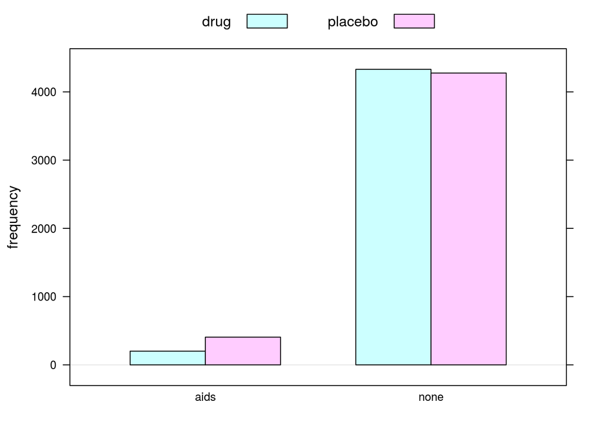

```r
DataF = filter(OldData,sex=="gal")
barchartGC(~infected + treatment, data= DataF)
```

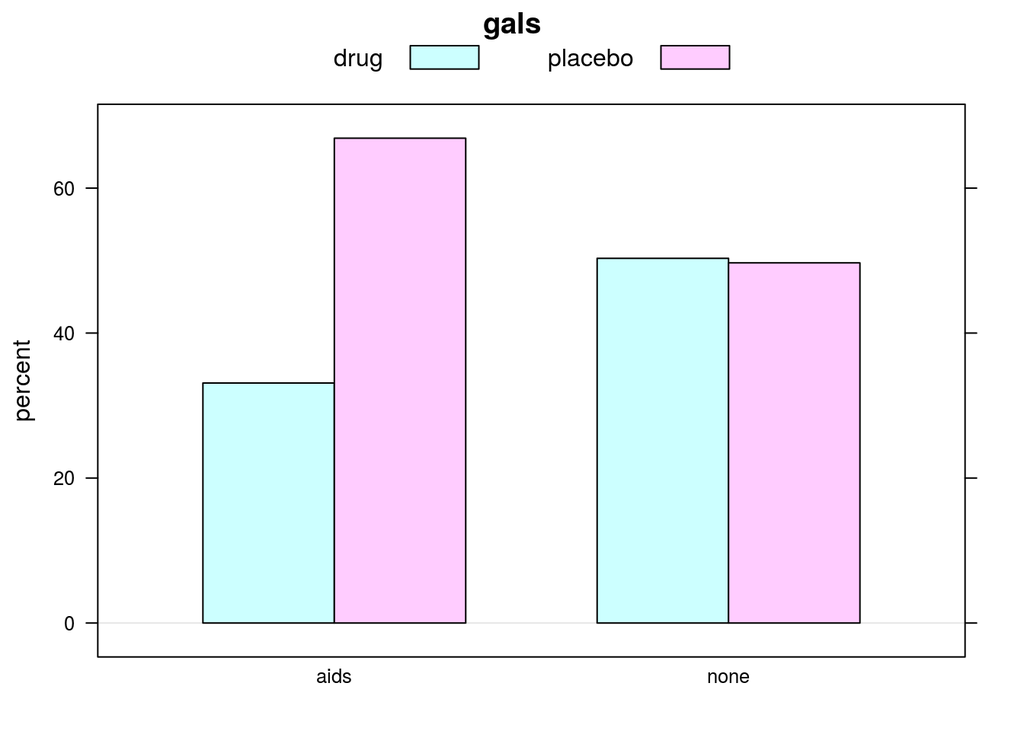

```r
barchartGC(~infected + treatment, data=DataF, type="percent",main="gals")
```

##Graphical Descriptive Results

Among females that contracted Aids twice as many took the placebo. Therefore it appears that the vaccine does have a positive effect.

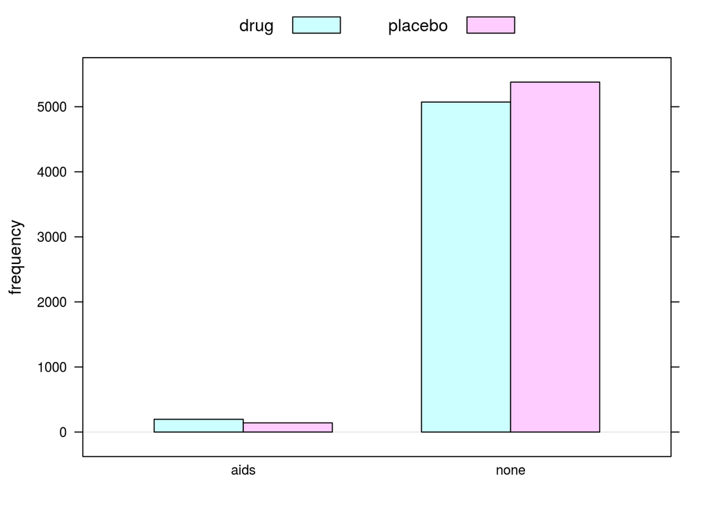

```r
DataG = filter(OldData,sex=="guy")
barchartGC(~infected + treatment, data= DataG)
```

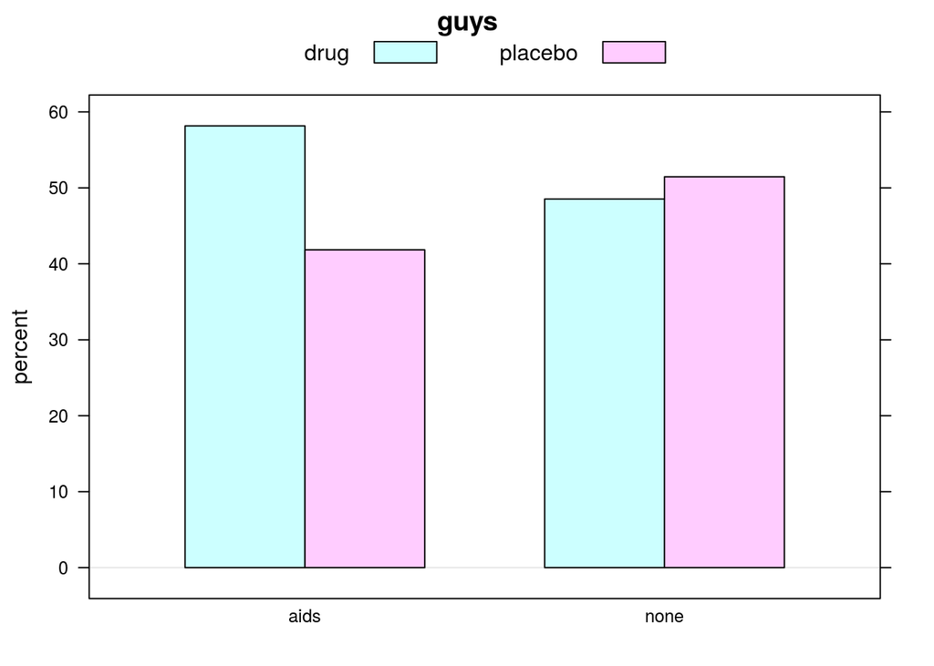

```r
barchartGC(~infected + treatment, data=DataG, type="percent",main="guys")
```

Its appears that the vaccine has a negative effect on the guys since they are more likely to get COVID19 if have the vaccine

##Graphical Descriptive Results

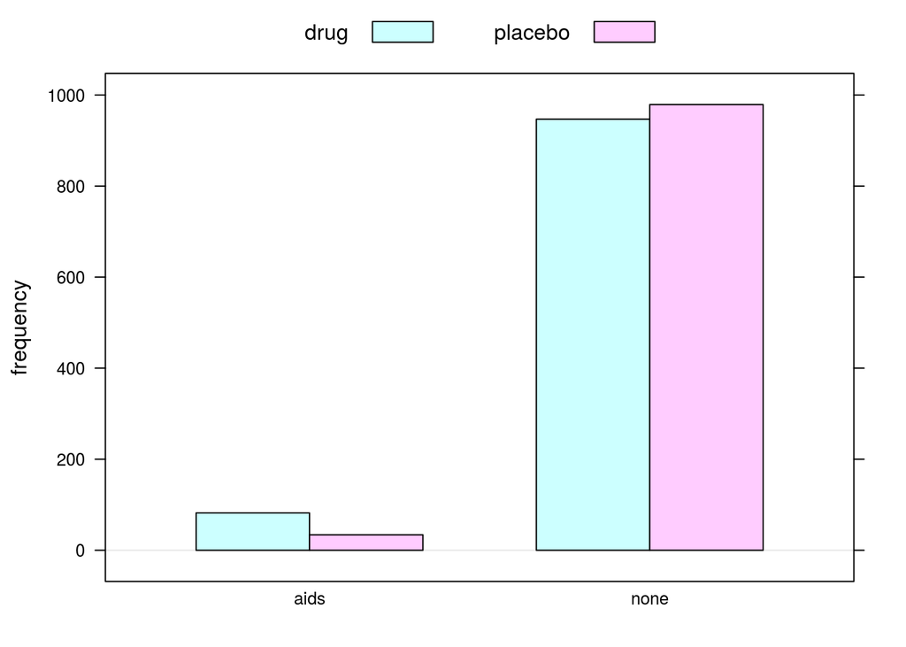

```r
DataGBTQ = filter(OldData,LGBTQ=="gay")
barchartGC(~infected + treatment, data= DataGBTQ)
```